# First_Analysis

Robin von Allmen

18 3 2021

## PCA Analysis

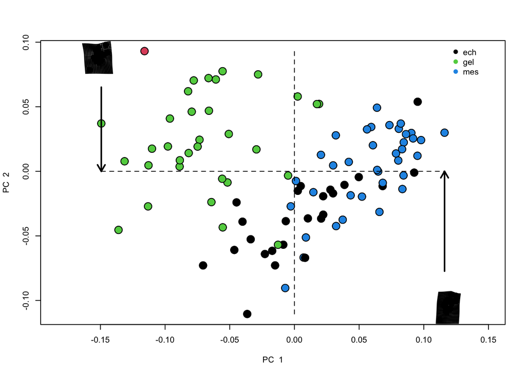

```r
PCA <-plotTangentSpace(proD$coords, groups=tribe, legend=T)
```

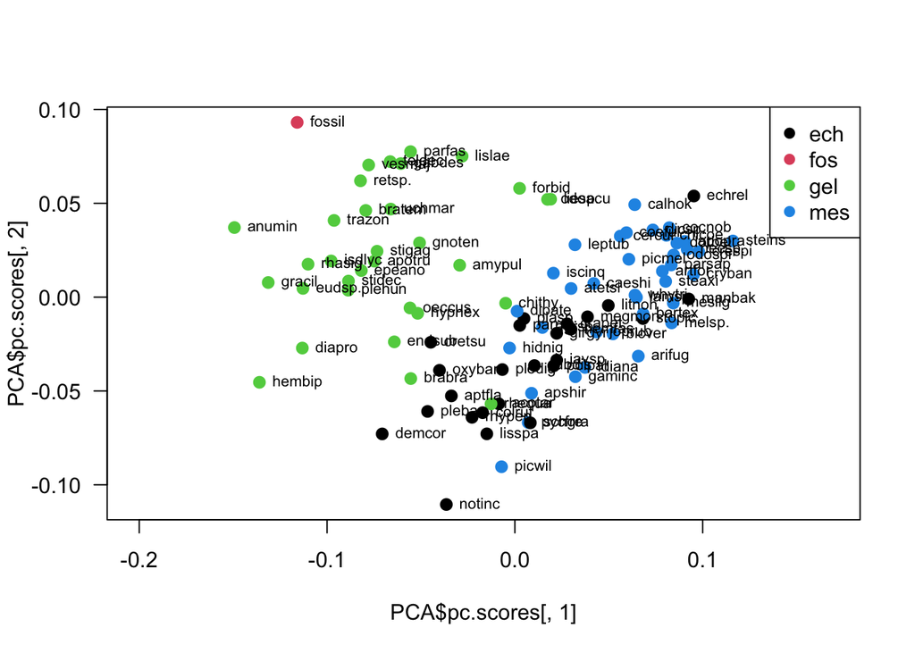

```r
#one can look at different PCA combinations to find the best model for its purpose
plot(PCA$pc.scores[,1],PCA$pc.scores[,2], col=tribe, asp=T, las=1,pch=16, cex=1.3)
legend("topright", legend= levels(tribe), col=palette(), pch=rep(19,14) )

# use the text() function to get the names of individual points
text(PCA$pc.scores[,1],PCA$pc.scores[,2],labels=species,cex=0.7,pos=4)
```

One can work on this plot to get a beautiful shape so that it loocks somewhat like this:

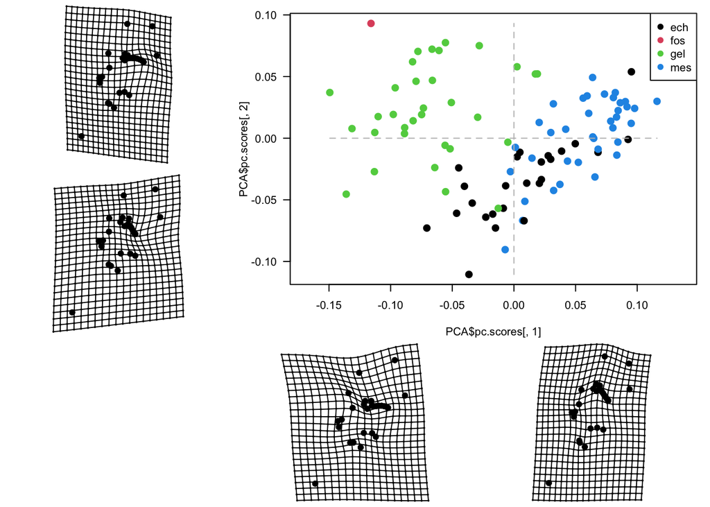

On the plot above we see, that Gelinae (Townes) are fairly good distinguishable from the other Tribes. The Data however does not represent modern taxonomy: Although most specimen still belong together in the same subfamily or Tribe, there has been a lot of improvement of building phenetic relationships between these genera together with molecular Data, hence some of the outliers in this plot that seem to belong in other groups, may actually be accounted to other taxanomic groups, as shown for the Genus Hemigaster for example.

with the PCA scores u are also able to generate 3d plots which compare several Principal Components at once:

```r
colors = c("red","cyan","magenta","yellow")[tribe]
plot3d(PCA$pc.scores[,1:3], col = colors, size = 9)
text3d(PCA$pc.scores[,1:3],texts=species,pos=4,cex= 0.6)
legend3d("topright", legend = c("Echthrini","Fossil", "Gelini", "Mesostenini"), col = c("red","cyan","magenta","yellow") , pch= 16)
```

[interactive chart not shown]

## Cluster Analysis

```r
data = data.frame(species, tribe, PCA$pc.scores[,1:6])

# Compute distances and hierarchical clustering
dd <- dist(scale(data[c(3:8)]), method = "euclidean")

## Ward's minimum variance method
hc <- hclust(dd, method = "ward.D2")

hc$labels = tribe

# Convert hclust into a dendrogram and plot
hcd <- as.dendrogram(hc)
```

## Dendrogramm

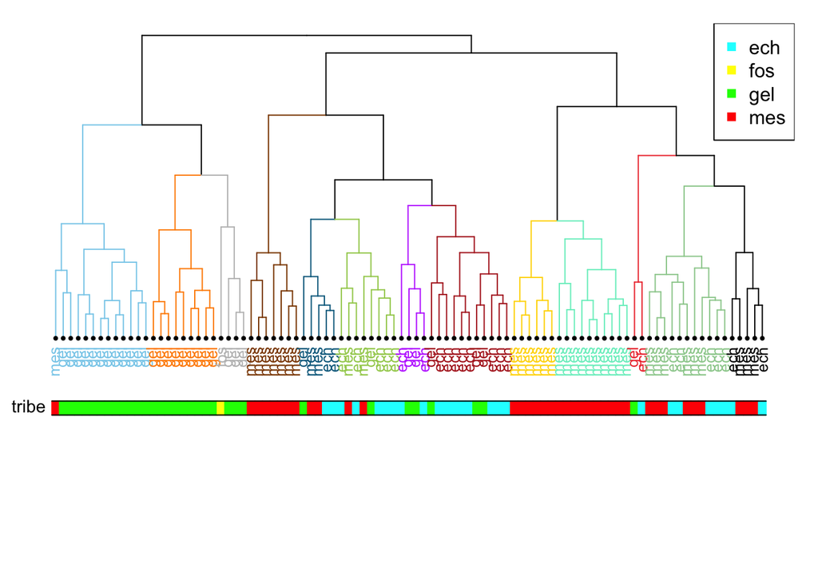

```r
require("dendextend") ## needs a dendrogram
#plot(hcd)

# Create a vector of colors, darkgreen if am is 0, green if 1.
my_colors <- ifelse(hc$labels=="ech", "cyan",ifelse(hc$labels=="gel","green", ifelse(hc$labels=="mes", "red","yellow")))
#my_colors <- ifelse(hc$labels=="scolob", "forestgreen",ifelse(hc$labels=="metopi", "green","yellow"))

par(mar=c(10,1,1,1))
hcd %>%
  set("labels_col", value = c("skyblue", "darkorange", "grey","darkorange4","deepskyblue4",
                              "darkolivegreen3","darkorchid1","firebrick","gold1","aquamarine2","brown2","darkseagreen3","black"), k=13) %>%
  set("branches_k_color", value = c("skyblue", "darkorange", "grey","darkorange4","deepskyblue4",
                                    "darkolivegreen3","darkorchid1","firebrick","gold1","aquamarine2","brown2","darkseagreen3","black"),k = 13) %>%
  set("labels_cex", 0.8)  %>%
  set("leaves_pch", 19)  %>%
  set("nodes_cex", 0.4) %>%
  plot(axes=FALSE)

# Add the colored bar
colored_bars(colors = my_colors, dend = hcd, rowLabels = "tribe")
legend("topright", legend=levels(tribe), col= c("cyan", "yellow", "green", "red"), pch=15)
```

For the creation of the Dendrogramm only the first 6 PC scores were considered, which contribute to about 82.5% of variation. Higher PC scores did not seem to reflect the data that would be observed on the PCA plots, as the fossil was usually clustered along with a specimen from Echthrini that in contrast was also clustered in Gelinae eventhough the fossil is much more distant from Echthrini than Gelinae.